# Redes Neuronales - Heart Disease

Sergio - Juan

2024-04-05

# Detección de Ataques al Corazón

Elegimos un conjunto de datos que proporciona información sobre **enfermedades cardíacas**.

Aplicando el algoritmo de redes neuronales el objetivo es predecir la probabilidad de los mismos.

## Cargamos las librerias a utilizar

```r
library(neuralnet)
library(readr)
library(tidyverse)#
library(corrplot) #
library(plotly)   #
library(caret)    # creación de entrenamiento de clasificación y regresión
library(caTools)  #
library(reshape2) #
library(corrplot)

library(nnet)

set.seed(189)
```

## Cargamos el conjunto de datos

```r
# Cargamos el dataset
heart <- read_csv("heartDisease/heart.csv")
```

### Analizamos la composición

```r
knitr::kable(head(heart))
```

| Age | Sex | ChestPainType | RestingBP | Cholesterol | FastingBS | RestingECG | MaxHR | ExerciseAngina | Oldpeak | ST_Slope | HeartDisease |
| --- | --- | --- | --- | --- | --- | --- | --- | --- | --- | --- | --- |
| 40 | M | ATA | 140 | 289 | 0 | Normal | 172 | N | 0.0 | Up | 0 |
| 49 | F | NAP | 160 | 180 | 0 | Normal | 156 | N | 1.0 | Flat | 1 |
| 37 | M | ATA | 130 | 283 | 0 | ST | 98 | N | 0.0 | Up | 0 |
| 48 | F | ASY | 138 | 214 | 0 | Normal | 108 | Y | 1.5 | Flat | 1 |
| 54 | M | NAP | 150 | 195 | 0 | Normal | 122 | N | 0.0 | Up | 0 |
| 39 | M | NAP | 120 | 339 | 0 | Normal | 170 | N | 0.0 | Up | 0 |

```r
# Age: Edad
# Sex: Género
# ChestPainType: TipoDolorPecho
# RestingBP: PresionSangreReposo
# Cholesterol: Colesterol
# FastingBS: AzucarSangreEnAyunas
# RestingECG: ElectroCardioGramaEnReposo
# MaxHR: FrecuenciaCardíacaMáxima
# ExerciceAngina: AnginaInducidaEnEjercicio
# Oldpeak: Valor del segmento ST
# ST_Slope: Pendiente del segmento ST
# HeartDisease: Enfermedad Cardiovascular
```

```r
knitr::kable(summary(heart))
```

|  | Age | Sex | ChestPainType | RestingBP | Cholesterol | FastingBS | RestingECG | MaxHR | ExerciseAngina | Oldpeak | ST_Slope | HeartDisease |
| --- | --- | --- | --- | --- | --- | --- | --- | --- | --- | --- | --- | --- |
|  | Min. :28.00 | Length:918 | Length:918 | Min. : 0.0 | Min. : 0.0 | Min. :0.0000 | Length:918 | Min. : 60.0 | Length:918 | Min. :-2.6000 | Length:918 | Min. :0.0000 |
|  | 1st Qu.:47.00 | Class :character | Class :character | 1st Qu.:120.0 | 1st Qu.:173.2 | 1st Qu.:0.0000 | Class :character | 1st Qu.:120.0 | Class :character | 1st Qu.: 0.0000 | Class :character | 1st Qu.:0.0000 |
|  | Median :54.00 | Mode :character | Mode :character | Median :130.0 | Median :223.0 | Median :0.0000 | Mode :character | Median :138.0 | Mode :character | Median : 0.6000 | Mode :character | Median :1.0000 |
|  | Mean :53.51 | NA | NA | Mean :132.4 | Mean :198.8 | Mean :0.2331 | NA | Mean :136.8 | NA | Mean : 0.8874 | NA | Mean :0.5534 |
|  | 3rd Qu.:60.00 | NA | NA | 3rd Qu.:140.0 | 3rd Qu.:267.0 | 3rd Qu.:0.0000 | NA | 3rd Qu.:156.0 | NA | 3rd Qu.: 1.5000 | NA | 3rd Qu.:1.0000 |
|  | Max. :77.00 | NA | NA | Max. :200.0 | Max. :603.0 | Max. :1.0000 | NA | Max. :202.0 | NA | Max. : 6.2000 | NA | Max. :1.0000 |

```r
str (heart)
```

```
## spc_tbl_ [918 × 12] (S3: spec_tbl_df/tbl_df/tbl/data.frame)
##  $ Age           : num [1:918] 40 49 37 48 54 39 45 54 37 48 ...
##  $ Sex           : chr [1:918] "M" "F" "M" "F" ...
##  $ ChestPainType : chr [1:918] "ATA" "NAP" "ATA" "ASY" ...
##  $ RestingBP     : num [1:918] 140 160 130 138 150 120 130 110 140 120 ...
##  $ Cholesterol   : num [1:918] 289 180 283 214 195 339 237 208 207 284 ...
##  $ FastingBS     : num [1:918] 0 0 0 0 0 0 0 0 0 0 ...
##  $ RestingECG    : chr [1:918] "Normal" "Normal" "ST" "Normal" ...
##  $ MaxHR         : num [1:918] 172 156 98 108 122 170 170 142 130 120 ...
##  $ ExerciseAngina: chr [1:918] "N" "N" "N" "Y" ...
##  $ Oldpeak       : num [1:918] 0 1 0 1.5 0 0 0 0 1.5 0 ...
##  $ ST_Slope      : chr [1:918] "Up" "Flat" "Up" "Flat" ...
##  $ HeartDisease  : num [1:918] 0 1 0 1 0 0 0 0 1 0 ...
##  - attr(*, "spec")=
##   .. cols(
##   ..   Age = col_double(),
##   ..   Sex = col_character(),
##   ..   ChestPainType = col_character(),
##   ..   RestingBP = col_double(),
##   ..   Cholesterol = col_double(),
##   ..   FastingBS = col_double(),
##   ..   RestingECG = col_character(),
##   ..   MaxHR = col_double(),
##   ..   ExerciseAngina = col_character(),
##   ..   Oldpeak = col_double(),
##   ..   ST_Slope = col_character(),
##   ..   HeartDisease = col_double()
##   .. )
##  - attr(*, "problems")=<externalptr>
```

```r
# Age: Edad
# Sex: Género
# ChestPainType: TipoDolorPecho
# RestingBP: PresionDeSangreEnReposo
# Cholesterol: Colesterol
# FastingBS: AzucarEnSangrEnAyunas
# RestingECG: ElectroCardioGramaEnReposo
# MaxHR: FrecuenciaCardíacaMáxima
# ExerciceAngina: AnginaEnEjercicio
# Oldpeak: Valor del segmento ST
# ST_Slope: Pendiente del segmento ST
# HeartDisease: Enfermedad Cardiovascular

# Este conjunto de datos contiene 11 variables relacionadas con el diagnóstico del paciente y una variable de resultado que indica la presencia o ausencia de enfermedad cardíaca
```

### Comenzamos con un analisis exploratorio de sus variables y su relación con la enfermedad.

### Sex

Es el género del paciente.

```r
knitr::kable(table(heart$Sex))
```

| Var1 | Freq |
| --- | --- |
| F | 193 |
| M | 725 |

Vemos que la muestra se encuentra desbalanceada, teniendo casi 4 hombres por cada mujer.

Analizamos la relación entre el género y la enfermedad:

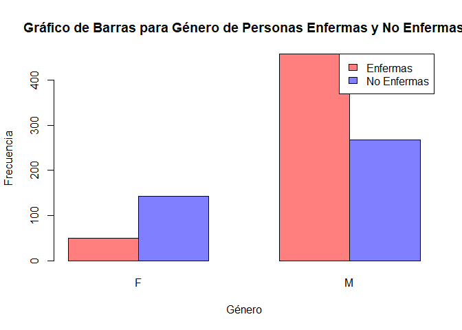

```r
# Calcular la frecuencia de grupos para personas enfermas
freq_enfermas <- table(heart$Sex[heart$HeartDisease == "1"])

# Calcular la frecuencia de grupos para personas no enfermas
freq_no_enfermas <- table(heart$Sex[heart$HeartDisease == "0"])

# Crear el gráfico de barras
barplot(rbind(freq_enfermas, freq_no_enfermas),
        beside = TRUE,
        col = c(rgb(1,0,0,0.5), rgb(0,0,1,0.5)),
        main = "Gráfico de Barras para Género de Personas Enfermas y No Enfermas",
        xlab = "Género",
        ylab = "Frecuencia",
        legend.text = c("Enfermas", "No Enfermas"),
        args.legend = list(x = "topright"))
```

Podemos ver que la frecuencia de aparición de enfermedades es mucho mayor en los hombres que en las mujeres.

Procedemos a convertirla la variable en numérica:

```r
heart$Sex <- ifelse(heart$Sex == "M", 1, 0)
knitr::kable(unique(heart$Sex))
```

| x |
| --- |
| 1 |
| 0 |

### RestingECG

Corresponde al resultado de un Electrocardiograma en reposo. Los valores posibles son:

```r
knitr::kable(unique(heart$RestingECG))
```

| x |
| --- |
| Normal |
| ST |
| LVH |

los cuales representan:

- Normal: Normal
- ST: having ST-T wave abnormality (T wave inversions and/or ST elevation or depression of > 0.05 mV) Las anomalías en las ondas ST-T pueden representar patología cardíaca o ser una variante normal. La interpretación de los hallazgos depende del contexto clínico.
- LVH: showing probable or definite left ventricular hypertrophy LVH (hipertrofia ventricular izquierda) se refiere al agrandamiento anormal del músculo del ventrículo izquierdo del corazón. Esto puede ser causado por condiciones como hipertensión arterial, enfermedad cardíaca o trastornos genéticos

Dado que son tres valores posibles, se realizará para esta variable una codificación del tipo OneHot.

Analizamos la frecuencia de enfermedades frente a esta variable:

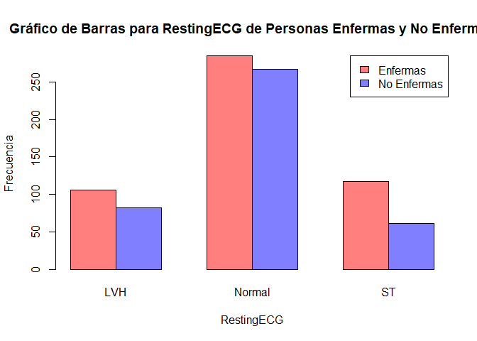

```r
# Calcular la frecuencia de grupos para personas enfermas
freq_enfermas <- table(heart$RestingECG[heart$HeartDisease == "1"])

# Calcular la frecuencia de grupos para personas no enfermas
freq_no_enfermas <- table(heart$RestingECG[heart$HeartDisease == "0"])

# Crear el gráfico de barras
barplot(rbind(freq_enfermas, freq_no_enfermas),
        beside = TRUE,
        col = c(rgb(1,0,0,0.5), rgb(0,0,1,0.5) ),
        main = "Gráfico de Barras para RestingECG de Personas Enfermas y No Enfermas",
        xlab = "RestingECG",
        ylab = "Frecuencia",
        legend.text = c("Enfermas", "No Enfermas"),
        args.legend = list(x = "topright"))
```

En este caso vemos que NO hay una clara relación entre una categoría y la frecuencia de aparición de enfermedades.

### ExerciseAngina

Representa los casos que tuvieron Angina durante el ejercicio o si el ejercicio indujo la misma.

```r
knitr::kable(table(heart$ExerciseAngina))
```

| Var1 | Freq |
| --- | --- |
| N | 547 |
| Y | 371 |

Analizamos la relación entre la variable y la aparición de la enfermedad:

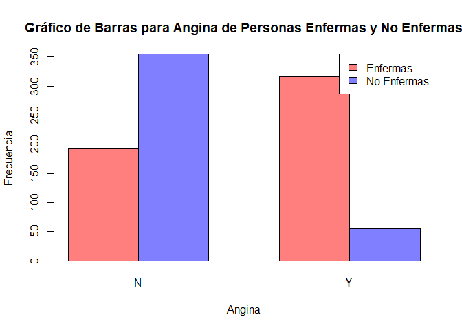

```r
# Calcular la frecuencia de grupos para personas enfermas
freq_enfermas <- table(heart$ExerciseAngina[heart$HeartDisease == "1"])

# Calcular la frecuencia de grupos para personas no enfermas
freq_no_enfermas <- table(heart$ExerciseAngina[heart$HeartDisease == "0"])

# Crear el gráfico de barras
barplot(rbind(freq_enfermas, freq_no_enfermas),
        beside = TRUE,
        col = c( rgb(1,0,0,0.5), rgb(0,0,1,0.5)),
        main = "Gráfico de Barras para Angina de Personas Enfermas y No Enfermas",
        xlab = "Angina",
        ylab = "Frecuencia",
        legend.text = c("Enfermas", "No Enfermas"),
        args.legend = list(x = "topright"))
```

Vemos que para las personas que presentan angina en ejercicio son mucho más frecuentes los ataques cardíacos.

Vemos que la variable presenta dos posibles valores, por lo que los convertimos a unos y ceros:

```r
heart$ExerciseAngina <- ifelse(heart$ExerciseAngina == "Y", 1, 0)
knitr::kable(unique(heart$ExerciseAngina))
```

| x |
| --- |
| 0 |
| 1 |

### ST_Slope

The slope of the peak exercise ST segment.

```r
knitr::kable(table(heart$ST_Slope))
```

| Var1 | Freq |
| --- | --- |
| Down | 63 |
| Flat | 460 |
| Up | 395 |

Los valores representan:

- Up: upsloping
- Flat: flat
- Down: downsloping

Analizamos la relación con la aparición de enfermedades:

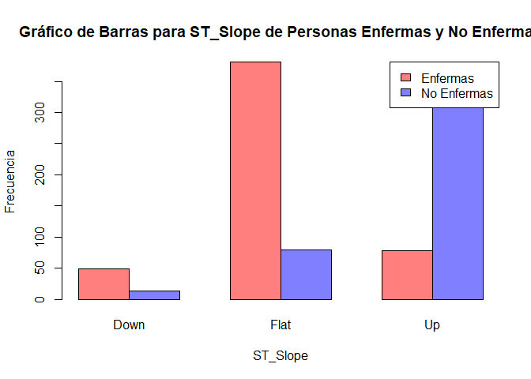

```r
# Calcular la frecuencia de grupos para personas enfermas
freq_enfermas <- table(heart$ST_Slope[heart$HeartDisease == "1"])

# Calcular la frecuencia de grupos para personas no enfermas
freq_no_enfermas <- table(heart$ST_Slope[heart$HeartDisease == "0"])

# Crear el gráfico de barras
barplot(rbind(freq_enfermas, freq_no_enfermas),
        beside = TRUE,
        col = c( rgb(1,0,0,0.5), rgb(0,0,1,0.5)),
        main = "Gráfico de Barras para ST_Slope de Personas Enfermas y No Enfermas",
        xlab = "ST_Slope",
        ylab = "Frecuencia",
        legend.text = c("Enfermas", "No Enfermas"),
        args.legend = list(x = "topright"))
```

Vemos que cuando no hay pendiente es cuando se presentan mayormente los casos de ataques cardíacos.

### ChestPainType

Representa el tipo de dolor en el pecho del paciente.

```r
knitr::kable(table(heart$ChestPainType))
```

| Var1 | Freq |
| --- | --- |
| ASY | 496 |
| ATA | 173 |
| NAP | 203 |
| TA | 46 |

Los valores posibles son:

- TA: Angina Típica
- ATA: Angina Atipica
- NAP: Dolor No-Anginal
- ASY: Asintomatico

Esta variable también se codificara con One Hot.

Analizamos la relación con los ataques cardíacos:

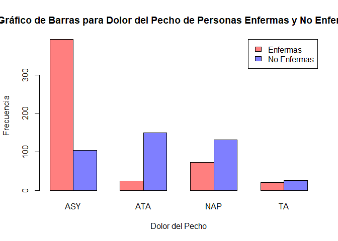

```r
# Calcular la frecuencia de grupos para personas enfermas
freq_enfermas <- table(heart$ChestPainType[heart$HeartDisease == "1"])

# Calcular la frecuencia de grupos para personas no enfermas
freq_no_enfermas <- table(heart$ChestPainType[heart$HeartDisease == "0"])

# Crear el gráfico de barras
barplot(rbind(freq_enfermas, freq_no_enfermas),
        beside = TRUE,
        col = c( rgb(1,0,0,0.5), rgb(0,0,1,0.5)),
        main = "Gráfico de Barras para Dolor del Pecho de Personas Enfermas y No Enfermas",
        xlab = "Dolor del Pecho",
        ylab = "Frecuencia",
        legend.text = c("Enfermas", "No Enfermas"),
        args.legend = list(x = "topright"))
```

Vemos que cuando tenemos casos asintomáticos son más frecuentes los ataques.

### Codificación las variables

Utilizamos la función dummy para crear variables dummy para realizar onehot encoding Las variables dummy son una técnica común en estadística y aprendizaje automático para representar datos categóricos o nominales de manera binaria. El proceso de one-hot encoding implica convertir cada categoría en una columna separada, donde se utiliza un valor # binario (0 o 1) para indicar si pertenece o no a esa categoría.

```r
dummy <- dummyVars(" ~ .", data=heart)
newdata <- data.frame(predict(dummy, newdata = heart))
newdata$ChestPainType <- NULL
newdata$RestingECG <- NULL
newdata$ST_Slope <- NULL
data <- newdata
```

Analizamos el dataframe resultante:

```r
knitr::kable(head(data))
```

| Age | Sex | ChestPainTypeASY | ChestPainTypeATA | ChestPainTypeNAP | ChestPainTypeTA | RestingBP | Cholesterol | FastingBS | RestingECGLVH | RestingECGNormal | RestingECGST | MaxHR | ExerciseAngina | Oldpeak | ST_SlopeDown | ST_SlopeFlat | ST_SlopeUp | HeartDisease |
| --- | --- | --- | --- | --- | --- | --- | --- | --- | --- | --- | --- | --- | --- | --- | --- | --- | --- | --- |
| 40 | 1 | 0 | 1 | 0 | 0 | 140 | 289 | 0 | 0 | 1 | 0 | 172 | 0 | 0.0 | 0 | 0 | 1 | 0 |
| 49 | 0 | 0 | 0 | 1 | 0 | 160 | 180 | 0 | 0 | 1 | 0 | 156 | 0 | 1.0 | 0 | 1 | 0 | 1 |
| 37 | 1 | 0 | 1 | 0 | 0 | 130 | 283 | 0 | 0 | 0 | 1 | 98 | 0 | 0.0 | 0 | 0 | 1 | 0 |
| 48 | 0 | 1 | 0 | 0 | 0 | 138 | 214 | 0 | 0 | 1 | 0 | 108 | 1 | 1.5 | 0 | 1 | 0 | 1 |
| 54 | 1 | 0 | 0 | 1 | 0 | 150 | 195 | 0 | 0 | 1 | 0 | 122 | 0 | 0.0 | 0 | 0 | 1 | 0 |
| 39 | 1 | 0 | 0 | 1 | 0 | 120 | 339 | 0 | 0 | 1 | 0 | 170 | 0 | 0.0 | 0 | 0 | 1 | 0 |

```r
str (data)
```

```
## 'data.frame':    918 obs. of  19 variables:
##  $ Age             : num  40 49 37 48 54 39 45 54 37 48 ...
##  $ Sex             : num  1 0 1 0 1 1 0 1 1 0 ...
##  $ ChestPainTypeASY: num  0 0 0 1 0 0 0 0 1 0 ...
##  $ ChestPainTypeATA: num  1 0 1 0 0 0 1 1 0 1 ...
##  $ ChestPainTypeNAP: num  0 1 0 0 1 1 0 0 0 0 ...
##  $ ChestPainTypeTA : num  0 0 0 0 0 0 0 0 0 0 ...
##  $ RestingBP       : num  140 160 130 138 150 120 130 110 140 120 ...
##  $ Cholesterol     : num  289 180 283 214 195 339 237 208 207 284 ...
##  $ FastingBS       : num  0 0 0 0 0 0 0 0 0 0 ...
##  $ RestingECGLVH   : num  0 0 0 0 0 0 0 0 0 0 ...
##  $ RestingECGNormal: num  1 1 0 1 1 1 1 1 1 1 ...
##  $ RestingECGST    : num  0 0 1 0 0 0 0 0 0 0 ...
##  $ MaxHR           : num  172 156 98 108 122 170 170 142 130 120 ...
##  $ ExerciseAngina  : num  0 0 0 1 0 0 0 0 1 0 ...
##  $ Oldpeak         : num  0 1 0 1.5 0 0 0 0 1.5 0 ...
##  $ ST_SlopeDown    : num  0 0 0 0 0 0 0 0 0 0 ...
##  $ ST_SlopeFlat    : num  0 1 0 1 0 0 0 0 1 0 ...
##  $ ST_SlopeUp      : num  1 0 1 0 1 1 1 1 0 1 ...
##  $ HeartDisease    : num  0 1 0 1 0 0 0 0 1 0 ...
```

Vemos que ahora contamos con más columnas, sin embargo, todas son numéricas.

### Age

Las edades de los pacientes se encuentran divididas de la siguiente manera:

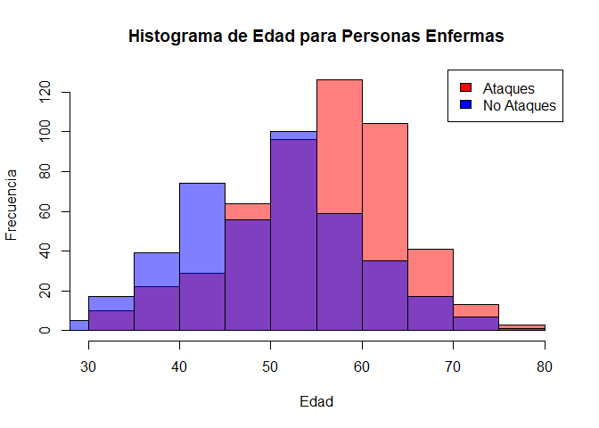

```r
# Crear el histograma
hist(data$Age[which(data$HeartDisease == "1")],
     col = rgb(1,0,0,0.5),
     main = "Histograma de Edad para Personas Enfermas",
     xlab = "Edad",
     ylab = "Frecuencia")

# Añadir histograma para personas no enfermas
hist(data$Age[which(data$HeartDisease == "0")],
     col = rgb(0,0,1,0.5),
     add = TRUE)

# Añadir leyenda
legend("topright",
       legend = c("Ataques", "No Ataques"),
       fill = c("red", "blue"))
```

De este grafico podemos concluir, algo que a intuitivamente se sabe, que es que la probabilidad de un ataque al corazón aumenta con el aumento de las edades. Esto no significa que sea imposible a edades menores, sólo que la frecuencia de aparición se incrementa.

### RestingBP

Es la presión arterial en estado de reposo, medida en mm de Hg.

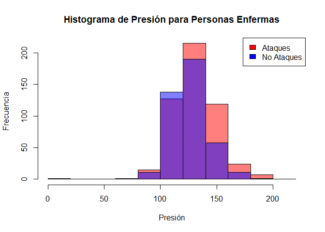

```r
# Obtener el rango de edad máximo y mínimo para ambos grupos
min_BP <- min(data$RestingBP)
max_BP <- max(data$RestingBP)

# Definir el número de intervalos deseado para el histograma
num_breaks <- 10  # Este número puede ajustarse según tus preferencias

# Calcular el ancho de los intervalos de clase
break_width <- (max_BP - min_BP) / num_breaks

# Calcular los puntos de corte para los intervalos de clase
breaks <- seq(min_BP, max_BP + break_width, by = break_width)

# Crear el histograma
hist(data$RestingBP[which(data$HeartDisease == "1")],
     col = rgb(1,0,0,0.5),
     main = "Histograma de Presión para Personas Enfermas",
     xlab = "Presión",
     ylab = "Frecuencia",
     breaks = breaks)

# Añadir histograma para personas no enfermas
hist(data$RestingBP[which(data$HeartDisease == "0")],
     col = rgb(0,0,1,0.5),
     add = TRUE,
     breaks = breaks)

# Añadir leyenda
legend("topright",
       legend = c("Ataques", "No Ataques"),
       fill = c("red", "blue"))
```

Vemos que al igual que con la edad, la frecuencia de aparición de ataques aumenta cuanto mayor es la presión sanguínea en estado de reposo.

### Cholesterol

Es el resultado de colesterol del paciente.

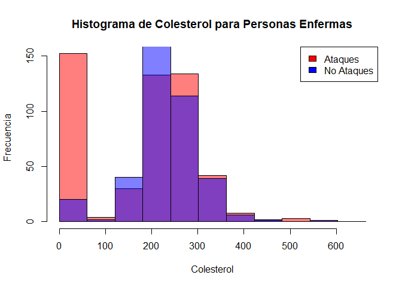

```r
# Obtener el rango de edad máximo y mínimo para ambos grupos
min_Col <- min(data$Cholesterol)
max_Col <- max(data$Cholesterol)

# Definir el número de intervalos deseado para el histograma
num_breaks <- 10  # Este número puede ajustarse según tus preferencias

# Calcular el ancho de los intervalos de clase
break_width <- (max_Col - min_Col) / num_breaks

# Calcular los puntos de corte para los intervalos de clase
breaks <- seq(min_Col, max_Col + break_width, by = break_width)

# Crear el histograma
hist(data$Cholesterol[which(data$HeartDisease == "1")],
     col = rgb(1,0,0,0.5),
     main = "Histograma de Colesterol para Personas Enfermas",
     xlab = "Colesterol",
     ylab = "Frecuencia",
     breaks = breaks)

# Añadir histograma para personas no enfermas
hist(data$Cholesterol[which(data$HeartDisease == "0")],
     col = rgb(0,0,1,0.5),
     add = TRUE,
     breaks = breaks)

# Añadir leyenda
legend("topright",
       legend = c("Ataques", "No Ataques"),
       fill = c("red", "blue"))
```

En este caso, tenemos dos puntos importantes a remarcar, si tenemos valores muy bajos de colesterol, lo cual se suele relacionar con un HDL inferior al recomendado, tenemos una gran concentración de enfermedades cardiovasculares. Por otro lado, en valores excesivamente altos, no se logra apreciar un incremento excesivo de casos.

### Fasting Blood Sugar

Es la concentración de azúcar en sangre en ayunas. Como podemos ver es una variable categórica, donde se coloca 1 si es mayor a 120 mg/dl y 0 en caso contrario.

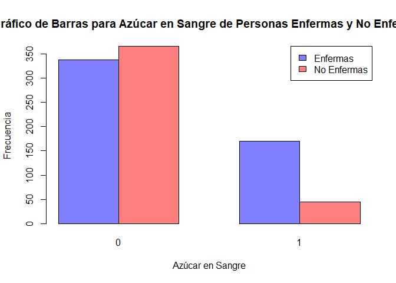

```r
# Calcular la frecuencia de grupos para personas enfermas
freq_enfermas <- table(data$FastingBS[data$HeartDisease == "1"])

# Calcular la frecuencia de grupos para personas no enfermas
freq_no_enfermas <- table(data$FastingBS[data$HeartDisease == "0"])

# Crear el gráfico de barras
barplot(rbind(freq_enfermas, freq_no_enfermas),
        beside = TRUE,
        col = c(rgb(0,0,1,0.5), rgb(1,0,0,0.5)),
        main = "Gráfico de Barras para Azúcar en Sangre de Personas Enfermas y No Enfermas",
        xlab = "Azúcar en Sangre",
        ylab = "Frecuencia",
        legend.text = c("Enfermas", "No Enfermas"),
        args.legend = list(x = "topright"))
```

Vemos claramente que un azucar elevado es un gran indicador de la posibilidad de sufrir un ataque.

### Max HR

Representa la máxima frecuencia cardíaca alguna vez alcanzada.

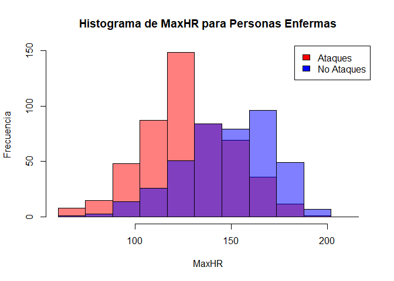

```r
# Obtener el rango de edad máximo y mínimo para ambos grupos
min_HR <- min(data$MaxHR)
max_HR <- max(data$MaxHR)

# Definir el número de intervalos deseado para el histograma
num_breaks <- 10  # Este número puede ajustarse según tus preferencias

# Calcular el ancho de los intervalos de clase
break_width <- (max_HR - min_HR) / num_breaks

# Calcular los puntos de corte para los intervalos de clase
breaks <- seq(min_HR, max_HR + break_width, by = break_width)

# Crear el histograma
hist(data$MaxHR[which(data$HeartDisease == "1")],
     col = rgb(1,0,0,0.5),
     main = "Histograma de MaxHR para Personas Enfermas",
     xlab = "MaxHR",
     ylab = "Frecuencia",
     breaks = breaks)

# Añadir histograma para personas no enfermas
hist(data$MaxHR[which(data$HeartDisease == "0")],
     col = rgb(0,0,1,0.5),
     add = TRUE,
     breaks = breaks)

# Añadir leyenda
legend("topright",
       legend = c("Ataques", "No Ataques"),
       fill = c("red", "blue"))
```

En este caso, contrintuitivamente, vemos que a una menor Frecuencia Cardíaca alcanzada, es más probable que tengas un atáque cardíaco.

### OldPeak

Es el valor numérico de la pendiente del sector ST del Electrocardiograma.

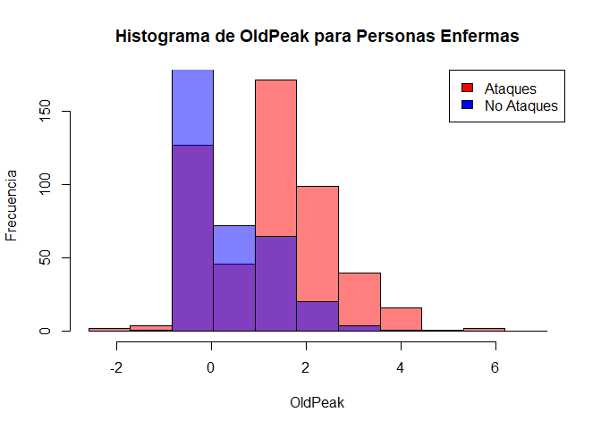

```r
# Obtener el rango de edad máximo y mínimo para ambos grupos
min_ST <- min(data$Oldpeak)
max_ST <- max(data$Oldpeak)

# Definir el número de intervalos deseado para el histograma
num_breaks <- 10  # Este número puede ajustarse según tus preferencias

# Calcular el ancho de los intervalos de clase
break_width <- (max_ST - min_ST) / num_breaks

# Calcular los puntos de corte para los intervalos de clase
breaks <- seq(min_ST, max_ST + break_width, by = break_width)

# Crear el histograma
hist(data$Oldpeak[which(data$HeartDisease == "1")],
     col = rgb(1,0,0,0.5),
     main = "Histograma de OldPeak para Personas Enfermas",
     xlab = "OldPeak",
     ylab = "Frecuencia",
     breaks = breaks)

# Añadir histograma para personas no enfermas
hist(data$Oldpeak[which(data$HeartDisease == "0")],
     col = rgb(0,0,1,0.5),
     add = TRUE,
     breaks = breaks)

# Añadir leyenda
legend("topright",
       legend = c("Ataques", "No Ataques"),
       fill = c("red", "blue"))
```

Podemos ver en este caso con claridad, que a valores mayores a 1 es mucho mayor la frecuencia de apparición de ataques cardíacos.

### Heart Disease

```r
data$HeartDisease -> heart$HeartDisease.as.factor
```

## Análisis de Correlaciones

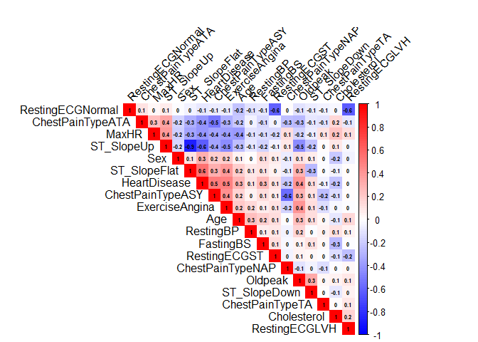

```r
# Cálculo de la matriz de correlación
matriz_cor <- cor(data)

# Personalizar la paleta de colores
mi_paleta <- colorRampPalette(c(rgb(0,0,1,0.5), "white", rgb(1,0,0,0.5)))(100)

# Crear el gráfico de matriz de correlación
corrplot(matriz_cor,
         method = "color",  # Usar colores para representar la magnitud de la correlación
         col = mi_paleta,  # Especificar la paleta de colores personalizada
         type = "upper",   # Mostrar solo la mitad superior de la matriz (evita duplicación de información)
         order = "hclust", # Ordenar las variables utilizando clustering jerárquico
         addCoef.col = "black", # Color del texto de los coeficientes de correlación
         tl.col = "black",      # Color de las etiquetas
         tl.srt = 45,          # Ángulo de inclinación de las etiquetas
         mar = c(0, 0, 2, 0),  # Ajustar los márgenes del gráfico
         number.digits = 1,
         number.cex = 0.5)
```

Vemos variables con altas correlaciones, especialmente entre las que surgieron del One Hot Encoder, sería una posibilidad eliminarlas.

## Dividir en Train y Test

```r
proporcion_train <- 0.7

# Dividir los datos en conjuntos de entrenamiento y prueba
indices <- createDataPartition(data$HeartDisease, p = proporcion_train, list = FALSE)
train_data <- data[indices, ]
test_data <- data[-indices, ]
```

## Estandarización de Variables

```r
# Estandarizar las variables en el conjunto de entrenamiento
train_data_scaled <- as.data.frame(scale(train_data[, -19]))  # Excluir la variable de respuesta (en este caso, Species)
attr(train_data_scaled, "scaled:center") <- colMeans(train_data[, -19])
attr(train_data_scaled, "scaled:scale") <- apply(train_data[, -19], 2, sd)

# Copiar la variable de respuesta al conjunto de datos estandarizado de entrenamiento
train_data_scaled$HeartDisease <- train_data$HeartDisease

# Estandarizar las variables en el conjunto de prueba usando los parámetros del conjunto de entrenamiento
test_data_scaled <- as.data.frame(scale(test_data[, -19], center = attr(train_data_scaled, "scaled:center"), scale = attr(train_data_scaled, "scaled:scale")))

# Copiar la variable de respuesta al conjunto de datos estandarizado de prueba
test_data_scaled$HeartDisease <- test_data$HeartDisease

#train_data_scaled$HeartDisease <- as.factor(train_data_scaled$HeartDisease)
```

## Red Neuronal

A partir de este dataset, lo que se busca es predecir la probabilidad de un ataque al corazón.

```r
# Definir control del entrenamiento con validación cruzada
ctrl <- trainControl(method = "cv", number = 5)

# Definir la cuadrícula de hiperparámetros
grid <- expand.grid(size = c(1, 2, 3, 4, 5, 10, 15), decay = c(0, 0.01, 0.1))

# Entrenar el modelo utilizando Grid Search
set.seed(123)
model <- train(HeartDisease ~ .,
               data = train_data_scaled,
               method = "nnet",
               linout = TRUE,  # Utilizar la función de activación lineal en la capa de salida
               trace = FALSE,  # Desactivar el seguimiento de iteraciones para mejorar la velocidad
               maxit = 1000,   # Número máximo de iteraciones
               trControl = ctrl,
               tuneGrid = grid)

# Mostrar los resultados
print(model)
```

```
## Neural Network
##
## 643 samples
##  18 predictor
##
## No pre-processing
## Resampling: Cross-Validated (5 fold)
## Summary of sample sizes: 514, 515, 514, 515, 514
## Resampling results across tuning parameters:
##
##   size  decay  RMSE       Rsquared   MAE
##    1    0.00   0.3875910  0.4874183  0.2766618
##    1    0.01   0.3453458  0.5236266  0.2132175
##    1    0.10   0.3287533  0.5655194  0.2053292
##    2    0.00   0.3585732  0.4982685  0.2164389
##    2    0.01   0.3489744  0.5222512  0.2142712
##    2    0.10   0.3419537  0.5373968  0.2161166
##    3    0.00   0.3873149  0.4475398  0.2246099
##    3    0.01   0.3534250  0.5230432  0.2153124
##    3    0.10   0.3607767  0.4968318  0.2388564
##    4    0.00   3.1739695  0.3382183  0.8019570
##    4    0.01   0.4117779  0.4169626  0.2389317
##    4    0.10   0.3559192  0.5070771  0.2367017
##    5    0.00   0.3971655  0.4173884  0.2575236
##    5    0.01   0.3708453  0.4873218  0.2469382
##    5    0.10   0.3834516  0.4644426  0.2439629
##   10    0.00   0.4808524  0.3065397  0.3496986
##   10    0.01   0.4836172  0.3418809  0.3404913
##   10    0.10   0.4225841  0.4078407  0.2955619
##   15    0.00   0.4965991  0.3092641  0.3712838
##   15    0.01   0.5549751  0.2900528  0.3951705
##   15    0.10   0.4503832  0.3777269  0.3128766
##
## RMSE was used to select the optimal model using the smallest value.
## The final values used for the model were size = 1 and decay = 0.1.
```

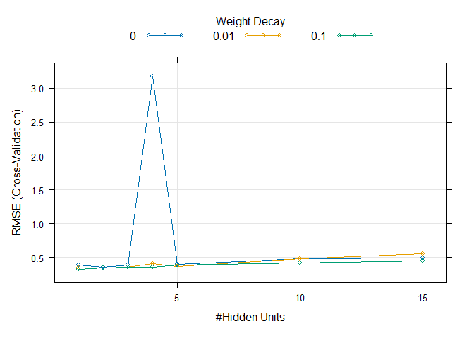

```r
plot(model)
```

```r
# Predecir clases en el conjunto de datos de prueba
test_data_scaled$predicciones <- predict(model, newdata = test_data_scaled)
test_data_scaled$predicciones <- ifelse(test_data_scaled$predicciones>0.5, 1, 0)
# Construir matriz de confusión
confusion <- table(Real = test_data_scaled$HeartDisease, Predicción = test_data_scaled$predicciones)

# Mostrar la matriz de confusión
knitr::kable(confusion)
```

|  | 0 | 1 |
| --- | --- | --- |
| 0 | 99 | 17 |
| 1 | 19 | 140 |

```r
      sexo <- c("masculino", "femenino")
      chestpain <- c("ASY", "ATA", "NAP", "TA")
      ECG <- c("Normal", "ST", "LVH")
      ST <- c("Down", "Flat", "UP")
      Ang <- c("Si", "No")
```

```r
column <- colnames(test_data[, -19])
dato <- matrix(c(35, 1, 1, 0, 0, 0, 145, 89, 50, 0, 0, 1, 190, 1, 4, 0, 1, 0 ),
                 nrow=1, ncol=18, byrow = T)
nuevos.normalizados <- as.data.frame(scale(dato, center = attr(train_data_scaled, "scaled:center"), scale = attr(train_data_scaled, "scaled:scale")))
names(nuevos.normalizados) <- column
prediccion <- predict(model, newdata = nuevos.normalizados)
```

```r
library(shiny)
```

```
## PhantomJS not found. You can install it with webshot::install_phantomjs(). If it is installed, please make sure the phantomjs executable can be found via the PATH variable.
```

```
##
## Listening on http://127.0.0.1:5166
```

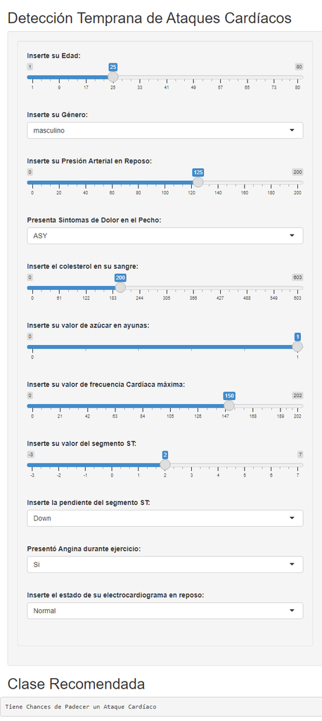

```r
#Define UI for application that draws a histogram
ui <- fluidPage(



  titlePanel('Detección Temprana de Ataques Cardíacos'),

  sidebarLayout(
    sidebarPanel(
      wellPanel(
          sliderInput("Edad", "Inserte su Edad:",
                  min = 1, max = 80, value = 25, step = 1),
          br(),

          selectInput('Sexo', 'Inserte su Género:', choices=sexo),
          br(),

          sliderInput("presion", "Inserte su Presión Arterial en Reposo:",
                  min = 0, max = 200, value = 125, step = 1),
          br(),

          selectInput('DolorPecho', 'Presenta Sintomas de Dolor en el Pecho:', choices=chestpain),
          br(),

          sliderInput("colesterol", "Inserte el colesterol en su sangre:",
                  min = 0, max = 603, value = 200, step = 1),
          br(),

          sliderInput("Azucar", "Inserte su valor de azúcar en ayunas:",
                  min = 0, max = 1, value = 1, step = 1),
          br(),

          sliderInput("MaxFrecuencia", "Inserte su valor de frecuencia Cardíaca máxima:",
                  min = 0, max = 202, value = 150, step = 1),
          br(),

          sliderInput("OldPeak", "Inserte su valor del segmento ST:",
                  min = -3, max = 7, value = 2, step = 0.1),
          br(),

          selectInput('STSlope', 'Inserte la pendiente del segmento ST:', choices=ST),
          br(),

          selectInput('Angina', 'Presentó Angina durante ejercicio:', choices=Ang),
          br(),

          selectInput('ECG', 'Inserte el estado de su electrocardiograma en reposo:', choices=ECG),
          br()
        )
    ),

    #Mostrar Ventas Estimadas
    mainPanel(
      h2("Clase Recomendada"),
      fluidRow(verbatimTextOutput("Clase"))
    )

  )


)



#Define server logic required to draw a histogram
server <- function(input, output) {
  clase_recomendada <- reactive({


      #Obtenemos los valores seleccionados
      edad <- input$Edad
      sexo <- input$Sexo
      presion <- input$presion
      dolorpecho <- input$DolorPecho
      colesterol <- input$colesterol
      azucar <- input$Azucar
      MAxFrecuencia <- input$MaxFrecuencia
      oldpeak <- input$OldPeak
      stslope <- input$STSlope
      angina <- input$Angina
      ecg <- input$ECG

      sexo1 <- ifelse(sexo == "masculino", 1, 0)
      azucar <- ifelse(azucar == "1", 1, 0)
      Ang1 <- ifelse(angina == "Si", 1, 0)
      ecgNormal <- ifelse(ecg == "Normal", 1, 0)
      ecgST <- ifelse(ecg == "ST", 1, 0)
      ecgLVH <- ifelse(ecg == "LVH", 1, 0)
      dolorASY <- ifelse(dolorpecho == "ASY", 1, 0)
      dolorATA <- ifelse(dolorpecho == "ATA", 1, 0)
      dolorNAP <- ifelse(dolorpecho == "NAP", 1, 0)
      dolorTA <- ifelse(dolorpecho == "TA", 1, 0)
      STDown <- ifelse(stslope == "Down", 1, 0)
      STFlat <- ifelse(stslope == "Flat", 1, 0)
      STUp <- ifelse(stslope == "Up", 1, 0)

      #attr(train_data_scaled, "scaled:center") <- colMeans(train_data[, -19])
#attr(train_data_scaled, "scaled:scale") <- apply(train_data[, -19], 2, sd)

      dato <- matrix(c(edad, sexo1, dolorASY, dolorATA, dolorNAP, dolorTA, presion, colesterol, azucar, ecgLVH, ecgNormal, ecgST, MAxFrecuencia, Ang1, oldpeak, STDown, STFlat, STUp ),
                 nrow=1, ncol=18, byrow = T)


      nuevos.normalizados <- as.data.frame(scale(dato, center = attr(train_data_scaled, "scaled:center"), scale = attr(train_data_scaled, "scaled:scale")))


names(nuevos.normalizados) <- column
    clase_recomendada <- ifelse(predict(model, newdata = nuevos.normalizados) >= 0.5, "Tiene Chances de Padecer un Ataque Cardíaco", "Tiene pocas probabilidades de Padecer un Ataque CArdíaco")
  })
  #Muestro la respuesta
  output$Clase <- renderText({

    clase_recomendada()
  })







}

# Run the aplication
shinyApp(ui = ui, server = server)
```